# act_report

## Report: act_report

#### Introduction

We stored the wrangled data in a CSV file named `twitter_archive_master.csv` ready for analysis and visualization.

- tweet_id
- timestamp
- source
- text
- expanded_urls
- rating_numerator
- rating_denominator
- name
- dog_class
- stage
- jpg_url
- img_num
- p1
- p1_conf
- p1_dog
- p2
- p2_conf
- p2_dog
- p3
- p3_conf
- p3_dog
- retweet_count
- favorite_count

#### Insights for Analysis

1. Which are the top breed of dogs?
2. What is the association between retweet count and favorite count?
3. Which class of dog got the highest retweet and favorite count?

#### Insight #1: Which are the top breed of dogs from the dataset

[figure not shown]

We check for the top ten dog breeds and categorize the rest in 'others'. The following result is obtained:

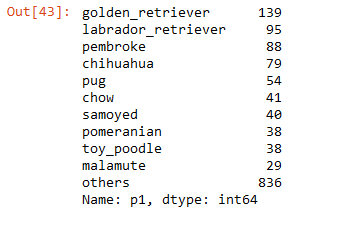

Golden retriever, labrador retriever and pembroke are the top three popular dog breeds. A display of this insight using a bar chart was produced as well.

[figure not shown]

#### Insight #2: What is the association between retweet count and favorite count?

We determine whether there is a relatonship between favorited tweets count and retweet count.

We apply Pearson's correlation coefficient formula which returns a value of 0.7 that suggests a fairly strong positive association between the two variables.

A scatter plot also dispays this notable relationship.

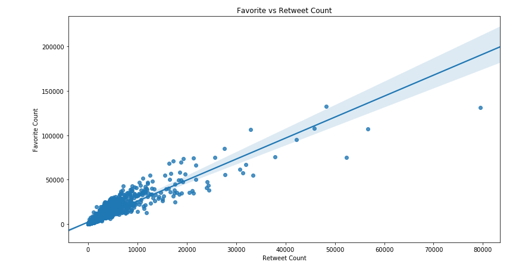

#### Insight #3: Which class of dog got the highest retweet and favorite count?

After determining an existing positive relationship between retweet count and favorite count, we examine which class of dogs from the given four, that is, doggo, floofer, pupper and puppo had the highest count of retweet and favorited.

Using mean to sort out the counts, we achieve the following:

[figure not shown]

[figure not shown]

#### Conclusion

More insights and visualizations can be produced from the data iteratively to get as much information as possible.